# Project 2

Henry Blassingame

# QuickStart Data Science Bootcamp Cohorts 3 and 4 - Jonathan Fowler

## Project 2 (R)

For this project, think of yourself as a developer on a corporate business intelligence team. You have been given a flat file (CSV format) of login information from Maximo, an asset tracking system the company relies on. Current licensing requires that no more than 95 users in the AUTHORIZED and/or LIMITED groups be online at any given time. The deliverables outlined in this project will be submitted to the IT director, who wants to be sure that the licensing threshold is not exceeded.

### The Data

The data is included in this project. The filename is **Project2Data.csv**.

| Field | Description |
| --- | --- |
| attemptdate | Date and Time of event |
| attemptresult | LOGIN, LOGOUT, TIMEOUT, or SYSLOGOUT |
| userid | The user triggering the event |
| type | User type, i.e., AUTHORIZED |
| maxsessionuid | Unique identifer for a session. |
|  | This will show up from LOGIN to LOGOUT, TIMEOUT, or SYSLOGOUT. |

### Part 1

Let’s answer some basic questions about the dataset. You may insert your code below each of these lines.

**Prework: Load the CSV file into your environment.**

```r
library(dplyr)
library(lubridate)
```

```r
library(ggplot2)
library(RColorBrewer)
LoginTracking_data <- read.csv("Project2Data.csv", header = TRUE, colClasses = c("character", "factor", "character", "factor", "integer"))
LoginTracking_data [duplicated(LoginTracking_data ),]
```

```
##               attemptdate attemptresult  userid       type maxsessionuid
## 2661  2020-03-02 16:08:06       TIMEOUT HBA2187    LIMITED        876350
## 4296  2020-03-03 11:06:46       TIMEOUT HBA2113    LIMITED        877346
## 5369  2020-03-03 15:40:10       TIMEOUT HBA1601 AUTHORIZED        877883
## 9822  2020-03-05 08:42:16       TIMEOUT HBA1966    EXPRESS        880823
## 10372 2020-03-05 11:20:23       TIMEOUT HBA2055 AUTHORIZED        880942
## 15634 2020-03-09 13:35:10       TIMEOUT HBA1782 AUTHORIZED        883431
## 15900 2020-03-09 14:48:11       TIMEOUT HBA1994 AUTHORIZED        883816
## 16970 2020-03-10 06:48:22       TIMEOUT HBA1903    LIMITED        883868
## 17736 2020-03-10 10:17:02       TIMEOUT HBA1942 AUTHORIZED        884371
## 18390 2020-03-10 13:35:40       TIMEOUT HBA1973 AUTHORIZED        884818
## 18804 2020-03-10 15:21:10       TIMEOUT HBA1946    LIMITED        884819
## 20064 2020-03-11 07:36:26       TIMEOUT HBA1917 AUTHORIZED        885000
## 21452 2020-03-11 14:33:12       TIMEOUT HBA1997    LIMITED        886408
## 22665 2020-03-12 07:10:21       TIMEOUT HBA2231 AUTHORIZED        886838
## 22799 2020-03-12 07:53:24       TIMEOUT HBA1978    LIMITED        887220
## 23372 2020-03-12 10:43:32       TIMEOUT HBA1601 AUTHORIZED        887302
## 33777 2020-03-19 08:23:53        LOGOUT HBA2243 AUTHORIZED        892534
## 39953 2020-03-23 09:57:23       TIMEOUT HBA1977 AUTHORIZED        895645
## 41772 2020-03-24 07:23:41       TIMEOUT HBA1697    LIMITED        895982
## 41856 2020-03-24 07:53:20       TIMEOUT HBA2168 AUTHORIZED        896616
## 42641 2020-03-24 12:34:08       TIMEOUT HBA2223    LIMITED        896565
## 50578 2020-03-28 10:29:43        FAILED HBA2006    LIMITED            NA
## 50585 2020-03-28 10:30:35        FAILED HBA2006    LIMITED            NA
## 54109 2020-03-30 16:22:40       TIMEOUT HBA2101    LIMITED        903231
```

NEXT STEP IS TO: 1. FILTER OUT SYSLOGOUT USERS 2. REMOVE ROWS WITH MAXSESSIONUID = 0 3. FILTER OUT ORPHAN RECORDS T BEGINNING AND END (USERS WHO LOGGED IN BEFORE MIDNIGHT BEFORE THE FIRST, OR LOGGED IN BEFORE THE END OF THE SET ) 4. REMOVE DUPLICATED RECORDS

```r
  filtered_data <- LoginTracking_data[LoginTracking_data$maxsessionuid != 0,]
  filtered_data <- filtered_data[!is.na(filtered_data$maxsessionuid),]
  filtered_data <- filtered_data [!duplicated(filtered_data ),]

  str(filtered_data)
```

```
## 'data.frame':    55260 obs. of  5 variables:
##  $ attemptdate  : chr  "2020-03-01 00:01:22" "2020-03-01 01:01:24" "2020-03-01 01:02:01" "2020-03-01 01:02:02" ...
##  $ attemptresult: Factor w/ 7 levels "FAILED","LOGIN",..: 6 6 6 6 2 7 2 2 7 7 ...
##  $ userid       : chr  "HBA1633" "HBA2266" "HBA1758" "HBA1726" ...
##  $ type         : Factor w/ 3 levels "AUTHORIZED","EXPRESS",..: 2 3 1 3 3 3 1 3 1 3 ...
##  $ maxsessionuid: int  873258 873665 873787 873366 873260 873260 873490 873893 873490 873893 ...
```

```r
  unique(filtered_data$attemptresult)
```

```
## [1] SYSLOGOUT LOGIN     TIMEOUT   LOGOUT    RESTART
## Levels: FAILED LOGIN LOGOUT RESTART SUCCESS SYSLOGOUT TIMEOUT
```

**1. How many unique users? A simple number will do here, no tables or formatting needed.**

```r
  length(unique(filtered_data$userid))
```

```
## [1] 762
```

**2. How many unique levels, unique users in each? I want a table that shows this information together.**

```r
  tapply(filtered_data$userid, filtered_data$type, FUN=function(x) length(unique(x)))
```

```
## AUTHORIZED    EXPRESS    LIMITED
##        141        196        425
```

**3. What is the average session time for each unique group?**

CREATE TWO NEW DATAFRAMES: PUT THE LOGINS IN ONE, AND THE SESSION ENDINGS IN ANOTHER - THE LOGINS FRAME IS BASED ON ATTEMPTRESULT = ‘LOGIN’ - THE LOGOUTS ARE BASED ON THE DIFFERENT POSSIBLE SESSION ENDINGS, KEEPING IN MIND THAT THERE MAY BE MORE THAN ONE RECORD FOR THESE SESSION END (AND AT DIFFERENT TIMES.)

```r
  logins <- filtered_data %>% filter(attemptresult == "LOGIN")
  logouts <- filtered_data %>% filter (attemptresult == "LOGOUT" | attemptresult == "TIMEOUT" | attemptresult == "RESTART" | attemptresult == "SYSLOGOUT")
```

*RATIONALE FOR DETERMINING SESSION LENGTH* IF THERE ARE MULTIPLE SESSION ENDINGS FOR THE SAME USER/SESSION, USE THE EARLIEST ONE AS THE SESSION END.THIS WILL BE USED TO DETERMINE THE SESSION LENGTH. IN LOOKING AT SOME OF THE DATA, THERE MIGHT BE A SYSLOGOUT MULTIPLE HOURS AFTER A USER LOGGED OUT OF MAXIMO OR TIMED OUT. THERE MAY ALSO BE CASES WHERE THERE IS ONLY A SYSLOGOUT FOR THE SESSION, SO THAT WILL BE THE RECORD USED TO DETERMINE SESSION LENGTH.

```r
  filter_out <- logouts %>% group_by(maxsessionuid) %>% filter(attemptdate == min(attemptdate))
  filter_out
```

```
## # A tibble: 26,466 x 5
## # Groups:   maxsessionuid [26,462]
##    attemptdate         attemptresult userid  type       maxsessionuid
##    <chr>               <fct>         <chr>   <fct>              <int>
##  1 2020-03-01 00:01:22 SYSLOGOUT     HBA1633 EXPRESS           873258
##  2 2020-03-01 01:01:24 SYSLOGOUT     HBA2266 LIMITED           873665
##  3 2020-03-01 01:02:01 SYSLOGOUT     HBA1758 AUTHORIZED        873787
##  4 2020-03-01 01:02:02 SYSLOGOUT     HBA1726 LIMITED           873366
##  5 2020-03-01 01:41:59 TIMEOUT       HBA1659 LIMITED           873260
##  6 2020-03-01 02:42:45 TIMEOUT       HBA1824 AUTHORIZED        873490
##  7 2020-03-01 02:57:50 TIMEOUT       HBA1789 LIMITED           873893
##  8 2020-03-01 03:17:56 LOGOUT        HBA1885 LIMITED           873903
##  9 2020-03-01 03:28:14 LOGOUT        HBA1726 LIMITED           873902
## 10 2020-03-01 03:54:42 LOGOUT        HBA2225 EXPRESS           874102
## # … with 26,456 more rows
```

BUILD THE SESSION DATA USING THE LOGINS AND LOGOUTS

```r
  session_data <- merge(logins, filter_out, by = "maxsessionuid")
```

DROP OFF THE CRUFTY BITS, SUCH AS COLUMNS THAT WILL NOT BE USED.

```r
  session_data$userid.y <- NULL
  session_data$type.y <- NULL
```

MAKE THE COLUMN NAMES MEANINGFUL

```r
  names(session_data) <-  c( "maxsessionid", "session_begin", "begin_type", "loginid", "user_type", "session_end", "end_type")
```

THEN SUSS OUT THE SESSION DURATION FIRST, CONVERT DATETIMES FROM CHARACTER STRINGS TO SOMETHING USEFUL. THEN GET THE DIFFERENCE BETWEEN SESSION END AND SESSION START

```r
  session_data$session_begin <- as_datetime(session_data$session_begin)
  session_data$session_end <- as_datetime(session_data$session_end)
  session_data$session_time <- difftime(session_data$session_end, session_data$session_begin, units = "mins")

  session_data %>% group_by(user_type) %>% summarize(AvgTimeSession = mean(session_time))
```

```
## # A tibble: 3 x 2
##   user_type  AvgTimeSession
##   <fct>      <drtn>
## 1 AUTHORIZED 38.02118 mins
## 2 EXPRESS    25.79384 mins
## 3 LIMITED    28.82214 mins
```

### Part 2

Your objective in this part is to create a Gantt chart that shows the following:  
1. One unique userid per row  
2. A Gantt chart on the right  
3. Blocks of time representing when each user logged in, mapped on the time field  
4. User’s time blocks colored by which group they belong to

You’re dealing with a lot of data, so a single chart that shows all users for the whole month would be impossible to read. How are you going to break this out into multiple, manageable charts? It’s okay to produce a chart for each week in the month. Just show the code that creates all the charts. **If you determine a Gantt chart is not appropriate, show me the Gantt anyway and then explain why your changes make sense.**

FIRST, BREAK DOWN THE DATA BY WEEK, SINCE A GANTT CHART FOR THE WHOLE MONTH IS IMPRACTICAL. DATA IS BASED ON THE STEPS ABOVE.

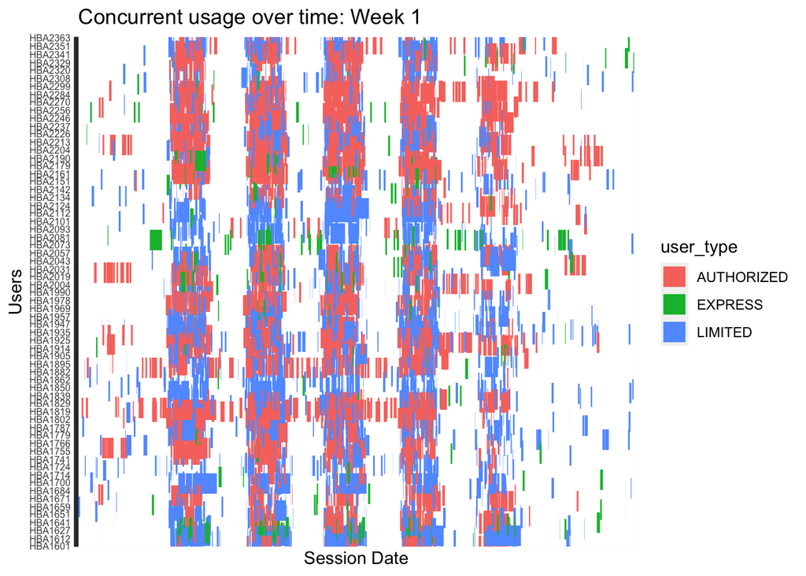

```r
first_week <- session_data[session_data$session_end < '2020-03-08 00:00', ]

ggplot(first_week, aes(x=session_begin , xend=session_end, y=loginid, yend=loginid, color=user_type)) + theme(axis.text.y = element_text(lineheight = 12, size = 6)) + scale_x_discrete(guide=guide_axis(check.overlap=TRUE)) + scale_y_discrete(guide=guide_axis(check.overlap=TRUE)) + geom_segment(size=6) + labs(title = "Concurrent usage over time: Week 1", x = "Session Date", y = "Users")
```

LOOKING AT THE FIRST WEEK OF DATA, IT IS APPARENT THAT IT IS UNINTELLIGIBLE. AS AN ALTERNATIVE, PRODUCE A LINE CHART BREAKING DOWN USAGE BY TYPE OVER TIME

```r
start_min <- min(session_data$session_begin, na.rm=T)
end_max <- max(session_data$session_end, na.rm=T)
t_int <-  seq.POSIXt(start_min, end_max, by = "1 mins")
```

GET TOTALS

```r
n_total <- sapply(t_int, function(tt) sum(session_data$session_begin <= tt & tt <= session_data$session_end))
```

GET DATA FOR AUTHORIZED USERS

```r
ds_auth <- session_data[session_data$user_type == "AUTHORIZED",]
n_auth <- sapply(t_int, function(tt) sum(ds_auth$session_begin <= tt & tt <= ds_auth$session_end))
```

GET DATA FOR LIMITED USERS

```r
ds_ltd <- session_data[session_data$user_type == "LIMITED",]
n_ltd <- sapply(t_int, function(tt) sum(ds_ltd$session_begin <= tt & tt <= ds_ltd$session_end))
```

GET DATA FOR EXPRESS USERS

```r
ds_exp <- session_data[session_data$user_type == "EXPRESS",]
n_exp  <- sapply(t_int, function(tt) sum(ds_exp$session_begin <= tt & tt <= ds_exp$session_end))
df_user <- data.frame(t_int, n_auth, n_ltd, n_exp)
df_total <- data.frame(t_int, n_total)
```

BUILD A DATA FRAME OF THE HIGH-WATER MARKS FOR ALL LICENSE TYPES, AS WELL AS OVERALL. THIS WILL GIVE A QUICK VIEW OF THE MAXIMUM USAGE

```r
df_highwater <- c("TOTAL" = max(n_total) , "AUTHORIZED" = max(n_auth), "LIMITED" = max(n_ltd), "EXPRESS" = max(n_exp) )
df_highwater
```

```
##      TOTAL AUTHORIZED    LIMITED    EXPRESS
##         95         59         44          8
```

BUILD THE PLOT FOR USAGE OVERALL AND BY LICENSE TYPE FOR THE MONTH

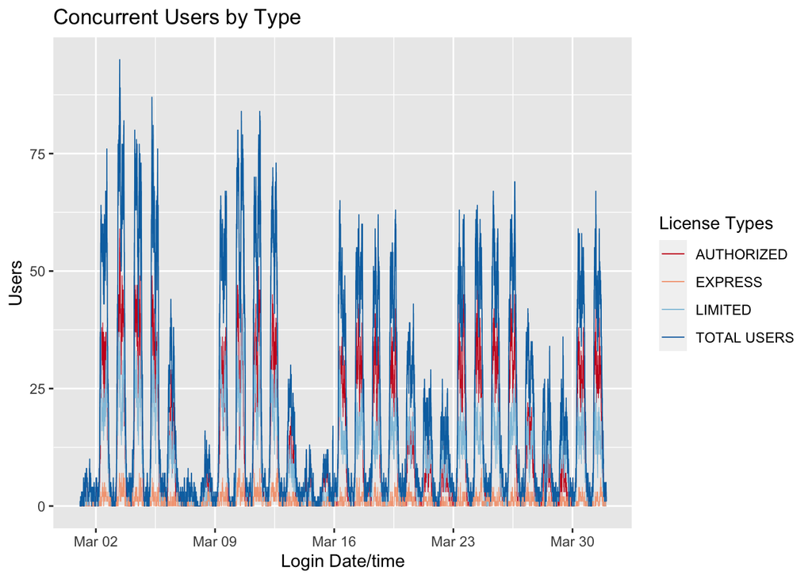

```r
ggplot(df_user) + geom_line(aes(color="AUTHORIZED", x=t_int, y=n_auth), size = 0.2) + geom_line(aes( color="LIMITED", x=t_int, y=n_ltd), size=0.2) + geom_line(aes(color="EXPRESS", x=t_int, y=n_exp), size=0.2) + geom_line(aes(color="TOTAL USERS", x=t_int, y=n_total), size=0.3) + labs(title="Concurrent Users by Type", x="Login Date/time", y="Users", color = "License Types") + theme_gray() + scale_color_brewer(palette="RdBu")
```

### Part 3

This project required you to think critically about the request(s) you were given, clarify information from the customer, and work together as a team. In the section below, please write a short paragraph that answers the following questions: 1. Did the Gantt chart request make sense? What was your process in determining how to show the data?  
2. What sort of cleaning did you have to do to the data? What data points did you remove and why?  
3. Did you find it difficult to ask the customer (me) clarifying questions?  
4. Did you take advantage of the student worksessions? How did those help you?  
5. How have you grown as a practitioner through the course of this project?

```
As an exercise in visualization the Gantt chart made sense. However, while it seemed to show an overall pattern
of system usage, it failed to account for the number of users in the system, nor the frequency of logins
(or brevity thereof.) In the end I decided to plot usage by license type over time, much as I do in my current
monthly Cocurrent Usage Report.

In general usage, however, I find that my management doesn't look at the visualizations of the data, but
focuses on the high water marks, to see how close peak usage is running compared to licensing, and then using
that number over several months to determine whether more licenses are needed, and to justify the number being
purchased.
This was also an interesting exercise in data cleaning, and especially in seeing how inconsistently the system
records LoginTracking data. For example, there were a large number of sessions with a SessionID of 0. These had
to be eliminated because there was no way to meaningfully correlate them. Despite several searches online, I
never found a reason for these. I may need to open a ticket to Support just to find out.

Another anomaly was that there were many cases where there were multiple endings for a single SessionID. My
method for cleaning these was to take the earliest among them, since generally the latter record was a
SYSLOGOUT, and occurred several hours after the previous session end.

Asking questions of the customer wasn't an issue, since it primarily involved questions relating to how the data
should be presented. This wasn't altogether different from my experience developing my original report in Excel,
since in that case it began with my manager asking for a way in which we could determine how many users were
using the system at any given time, and how many of each license type were in use. After spenfing some time
looking at the available data, building some test queries, and quite a bit of time thinking about the problem,
I had a result I could present to my manager. He and I worked together -- with him asking questions to better
understand the result, and then looking into specific instances to verify the data -- and after several
iterations produced the Excel sheet I presented earlier in class.

The online work sessions during this project were invaluable. There were several times I had questions or doubts
(for example, formatting this markdown document), and through talking about the problems I had and sharing my
screen with the others, I found that the way I had the document formatted was incorrect. (I wondered why the
syntax highlighting didn't work, and why strings between dollar signs looked funny.) In addition, there were
several times that I was able to share things I had learned with others in the session.

In general, the experience wasn't all that different from my day-to-day work. I have been in IT since the late
80s and a developer since the late 90s, and currently work in a team of about 10 people. We're all well-versed
in the applications we support, but each of us tend to specialize somewhat in our particular areas. In addition,
there are several other applications within our portfolio that some of us support, while others do not. Our
work comes in through a ticketing system, and we either take incoming tickets based on our specialization and
workload, or they will be assigned to us. Since we're a team, we regularly have informal discussions among
ourselves to discuss problems we're working on, solutions we've tried, or to brainstorm new ideas. We also
share knowledge in semi-formal lunch and learn sessions to cross-train the team.

Growth... In general, based on the above, I think my growth so far has been more a matter of increments rather
than leaps forward. I think my largest growth has been in becoming more comfortable with using R and its
attendant pacakges as a problem solving tool, and more recently in becoming more familiar with markdown,
which I had not used before. This has also given me some ideas for taking the "bones" of this project
and using them to build a more robust concurrent usage application that can run without as much
manual intervention as my current solution.
```

### Submissions

Because we all will be working with the same data, you will only need to send me an updated version of this Markdown file. Please save it as *lastname_firstinitial_Project2.Rmd* and email to me directly at jonathan.fowler@quickstart.com. Submissions must be made by **May 22 2020 11:59PM ET**.

### Resources

#### Gantt charts

https://www.statology.org/gantt-chart-r-ggplot2/  
https://stats.andrewheiss.com/misc/gantt.html  
https://davetang.org/muse/2017/02/03/gantt-chart-using-r/  
https://datascienceplus.com/visualize-your-cvs-timeline-with-r-gantt-style/  
https://edwinth.github.io/blog/paletti/ https://drsimonj.svbtle.com/creating-corporate-colour-palettes-for-ggplot2 http://www.sthda.com/english/wiki/ggplot2-colors-how-to-change-colors-automatically-and-manually